# lab2

**Практическое задание №2 по курсу "Методы и технологии машинного обучения"**

*Арешин Станислав Олегович М8О-111М-21*

**Задание**

- Построить несколько алгоритмов классификации (KNN, SVM, LogReg)
- Для каждого алгоритма построить кривые обучения. Сделать выводы о качестве модели и выборки.
- Для одного из алгоритмов сделать поиск двух гиперпараметров по двумерной сетке. Визуализировать сетку.

```python
import pandas as pd
import numpy as np
import matplotlib.pyplot as plt
import seaborn as sns

sns.set_style("darkgrid", {"grid.color": ".6", "grid.linestyle": ":"})

%matplotlib inline
```

# Предобработка

## Загрузка данных

Для второй лабораторной работы я решил взять тот же датасет

Датасет https://www.kaggle.com/sveneschlbeck/nba-players-career-duration

Успех новичка НБА зависит от многих переменных - особенно от его игры в первом сезоне. Иногда можно использовать статистические данные о таких игроках, чтобы предсказать, проживут ли они 5 лет в НБА или нет.

Соответственно, целевая величина target_5yrs.

Сразу удалим признак name, так как это имя баскетболиста - уникальный идентификатор.

```python
df = pd.read_csv('nba-players.csv').drop(['Unnamed: 0', 'name'], axis = 1)
df.head()
```

|  | gp | min | pts | fgm | fga | fg | 3p_made | 3pa | 3p | ftm | fta | ft | oreb | dreb | reb | ast | stl | blk | tov | target_5yrs |
| --- | --- | --- | --- | --- | --- | --- | --- | --- | --- | --- | --- | --- | --- | --- | --- | --- | --- | --- | --- | --- |
| 0 | 36 | 27.4 | 7.4 | 2.6 | 7.6 | 34.7 | 0.5 | 2.1 | 25.0 | 1.6 | 2.3 | 69.9 | 0.7 | 3.4 | 4.1 | 1.9 | 0.4 | 0.4 | 1.3 | 0 |
| 1 | 35 | 26.9 | 7.2 | 2.0 | 6.7 | 29.6 | 0.7 | 2.8 | 23.5 | 2.6 | 3.4 | 76.5 | 0.5 | 2.0 | 2.4 | 3.7 | 1.1 | 0.5 | 1.6 | 0 |
| 2 | 74 | 15.3 | 5.2 | 2.0 | 4.7 | 42.2 | 0.4 | 1.7 | 24.4 | 0.9 | 1.3 | 67.0 | 0.5 | 1.7 | 2.2 | 1.0 | 0.5 | 0.3 | 1.0 | 0 |
| 3 | 58 | 11.6 | 5.7 | 2.3 | 5.5 | 42.6 | 0.1 | 0.5 | 22.6 | 0.9 | 1.3 | 68.9 | 1.0 | 0.9 | 1.9 | 0.8 | 0.6 | 0.1 | 1.0 | 1 |
| 4 | 48 | 11.5 | 4.5 | 1.6 | 3.0 | 52.4 | 0.0 | 0.1 | 0.0 | 1.3 | 1.9 | 67.4 | 1.0 | 1.5 | 2.5 | 0.3 | 0.3 | 0.4 | 0.8 | 1 |

```python
df.info()
```

```
<class 'pandas.core.frame.DataFrame'>
RangeIndex: 1340 entries, 0 to 1339
Data columns (total 20 columns):
 #   Column       Non-Null Count  Dtype
---  ------       --------------  -----
 0   gp           1340 non-null   int64
 1   min          1340 non-null   float64
 2   pts          1340 non-null   float64
 3   fgm          1340 non-null   float64
 4   fga          1340 non-null   float64
 5   fg           1340 non-null   float64
 6   3p_made      1340 non-null   float64
 7   3pa          1340 non-null   float64
 8   3p           1340 non-null   float64
 9   ftm          1340 non-null   float64
 10  fta          1340 non-null   float64
 11  ft           1340 non-null   float64
 12  oreb         1340 non-null   float64
 13  dreb         1340 non-null   float64
 14  reb          1340 non-null   float64
 15  ast          1340 non-null   float64
 16  stl          1340 non-null   float64
 17  blk          1340 non-null   float64
 18  tov          1340 non-null   float64
 19  target_5yrs  1340 non-null   int64
dtypes: float64(18), int64(2)
memory usage: 209.5 KB
```

Пропущенных значений нет, все признаки числовые. Итого имеем 19 признаков и целевую величину.

## Баланс целевой величины

Построим график баланса целевой величины

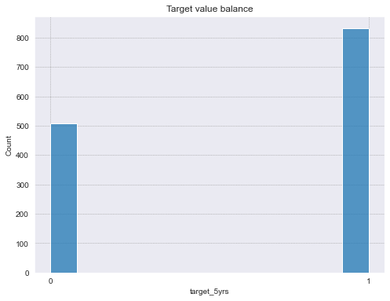

```python
plt.figure(figsize=(8,6))
plt.title('Target value balance')
sns.histplot(data=df, x='target_5yrs')
plt.xticks([0,1])
plt.show()
```

Видно, что целевая величина не очень хорошо сбалансирована. Поэтому лучший алгоритм будем выбирать по метрике f1, так как accuracy плохо показывает качество алгоритма на несбалансированной выборке.

При обучении алгоритмов, где возможно, стоит указать параметр class_weight = 'balanced' для корректного обучения алгоритма на несбалансированной выборке.

При выполнении train test split стоит указать параметр stratify по целевой величине, чтобы гарантировать примерно одинаковый баланс целевой величины в обучении и тесте.

## Выделение целевой величины

```python
y = df['target_5yrs'].to_numpy()
X = df.drop(['target_5yrs'], axis = 1).to_numpy()

X.shape, y.shape
```

```
((1340, 19), (1340,))
```

## Нормализация

В этот раз решил центрировать и нормировать признаки, так как во-первых, метрический алгоритм knn чувствителен к масштабу признаков и лучше их привести к одной шкале, а во-вторых, это снизит вклад возможных выбросов для svm и logreg, и линейные методы также лучше работают с данными в одной шкале.

```python
from sklearn.preprocessing import StandardScaler

X_scaled = StandardScaler().fit_transform(X)

X_scaled
```

```
array([[-1.40090082,  1.17706613,  0.13740097, ..., -0.53345799,
         0.07325418,  0.14733795],
       [-1.45828144,  1.11686044,  0.09148643, ...,  1.17550237,
         0.30641476,  0.56269458],
       [ 0.77956287, -0.27991152, -0.36765896, ..., -0.28932079,
        -0.1599064 , -0.26801868],
       ...,
       [-0.99923645, -0.66522792, -0.32174442, ..., -0.77759518,
         0.07325418, -0.40647089],
       [-0.48281084, -0.67726906, -0.52835985, ..., -0.53345799,
        -0.62622755, -0.5449231 ],
       [-0.76971396, -0.71339247, -0.55131712, ...,  0.19895359,
        -0.62622755, -0.40647089]])
```

## Train-test split

```python
from sklearn.model_selection import train_test_split
X_train, X_test, y_train, y_test = train_test_split(X_scaled, y, test_size = 0.33,
                                                    random_state = 42,  stratify = y)
```

```python
X_train.shape, y_train.shape
```

```
((897, 19), (897,))
```

```python
X_test.shape, y_test.shape
```

```
((443, 19), (443,))
```

В целом я не очень люблю обучать алгоритмы "из коробки", поэтому по минимуму переберу несколько гиперпараметров для каждого алгоритма, чтобы найти наилучшие.

# KNN

Начнём с метрического алгоритма KNN

## Grid Search

С помощью поиска гиперпараметров по сетке я решил перебрать несколько метрик расстояния и количество ближайших соседей для алгоритма KNN, так как результат классификации сильно зависит от кол-ва соседей и от того, как вычисляется расстояние, а алгоритм с дефолтными параметрами обычно работает не очень хорошо. Кроме того, я потестил взвешенный алгоритм и пришёл к выводу, что в данной задаче лучше всего результаты у невзвешенного KNN, поэтому перебирать буду только нечетное кол-во соседей.

*Сетка для соседей: 1, 3, 5, 7, 9, 11, 13, 15, 17, 19, 21, 23, 25, 27, 29*

*Сетка для метрик расстояния: Евклидово расстояние, Манхэттенское расстояние и расстояние Чебышева.*

*Оценивание по метрике f1 с помощью кросс валидации на 5 фолдах*

```python
from sklearn.neighbors import KNeighborsClassifier
from sklearn.model_selection import GridSearchCV

grid = {'n_neighbors': np.arange(1, 31, step = 2, dtype='int'),
        'metric' : ('euclidean', 'manhattan', 'chebyshev')
       }

model = KNeighborsClassifier()

gs = GridSearchCV(model, param_grid=grid, scoring='f1', cv = 5, n_jobs=-1)

gs.fit(X_train, y_train)
```

```
GridSearchCV(cv=5, estimator=KNeighborsClassifier(), n_jobs=-1,
             param_grid={'metric': ('euclidean', 'manhattan', 'chebyshev'),
                         'n_neighbors': array([ 1,  3,  5,  7,  9, 11, 13, 15, 17, 19, 21, 23, 25, 27, 29])},
             scoring='f1')
```

Визуализируем полученный результат по двумерной сетке параметров:

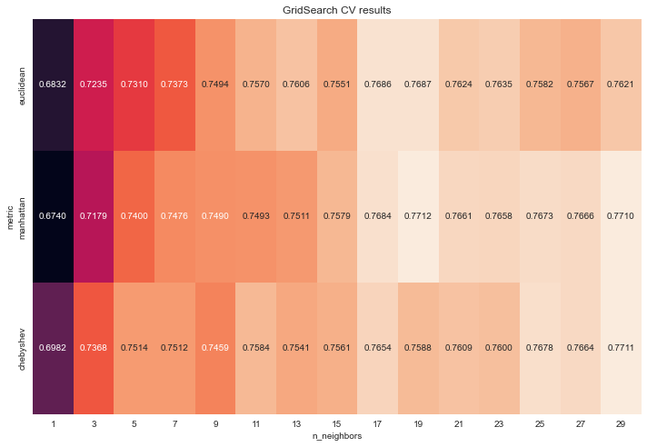

```python
score = gs.cv_results_['mean_test_score'].reshape(len(grid['metric']), len(grid['n_neighbors']))

plt.figure(figsize=(12,8))
plt.title('GridSearch CV results')
sns.heatmap(score, cbar=False, annot=True, fmt= '.4f',
            yticklabels= grid['metric'], xticklabels= grid['n_neighbors'])
plt.xlabel('n_neighbors')
plt.ylabel('metric')
plt.show()
```

Чем светлее ячейка, тем лучше результат на кросс валидации, но видно несколько светлых ячеек, поэтому было решено также вывести значения в ячейках, чтобы однозначно визуально видеть лучшие параметры.

Таким образом, лучший скор при $metric = 'manhattan'$, $n\_neighbors = 19$, при таких гиперпараметрах $f1score = 0.7712$

Также выведем лучшие результаты grid search, видно, что они совпадают:

```python
gs.best_params_, gs.best_score_
```

```
({'metric': 'manhattan', 'n_neighbors': 19}, 0.7712167444540812)
```

## Learning Curves

По модели с лучшими параметрами построим кривые обучения

```python
from sklearn.neighbors import KNeighborsClassifier
from sklearn.model_selection import learning_curve

model = KNeighborsClassifier(n_neighbors=19, metric='manhattan')

train_sizes, train_scores, test_scores, fit_times, _ = learning_curve(model, X_train, y_train,
                                                         train_sizes=np.linspace(0.1, 1.0, 10), cv=5,
                                                         n_jobs=-1, scoring='f1', return_times=True)

train_scores_mean = np.mean(train_scores, axis=1)
train_scores_std = np.std(train_scores, axis=1)

test_scores_mean = np.mean(test_scores, axis=1)
test_scores_std = np.std(test_scores, axis=1)

fit_times_mean = np.mean(fit_times, axis=1)
fit_times_std = np.std(fit_times, axis=1)
```

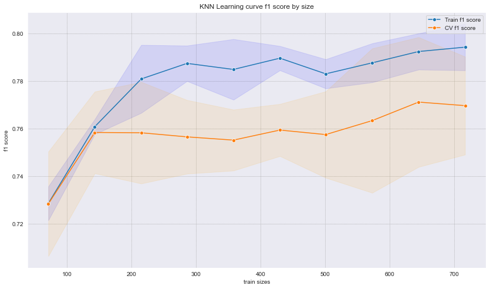

```python
plt.figure(figsize=(14,8))
plt.title('KNN Learning curve f1 score by size')

sns.lineplot(x=train_sizes, y=train_scores_mean, marker='o')
plt.fill_between(train_sizes,train_scores_mean + train_scores_std,
                 train_scores_mean - train_scores_std, alpha = 0.1, color="b")

sns.lineplot(x=train_sizes, y=test_scores_mean, marker='o')
plt.fill_between(train_sizes, test_scores_mean + test_scores_std,
                 test_scores_mean - test_scores_std, alpha = 0.1, color='orange')

plt.legend(['Train f1 score', 'CV f1 score'])
plt.xlabel('train sizes')
plt.ylabel('f1 score')
plt.show()
```

Видно, что кривые обучения и валидации стремятся к 1, но не достигают её. Это говорит о том, что недостаточно данных для хорошего обучения модели, хотя в целом такой модели достаточно для данной задачи.

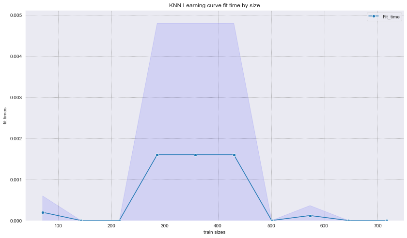

```python
plt.figure(figsize=(14,8))
plt.title('KNN Learning curve fit time by size')

sns.lineplot(x=train_sizes, y=fit_times_mean,  marker='o')
plt.fill_between(train_sizes, fit_times_mean + fit_times_std,
                 fit_times_mean - fit_times_std, alpha = 0.1, color="b")


plt.legend(['Fit_time'])
plt.xlabel('train sizes')
plt.ylabel('fit times')
plt.ylim(0)
plt.show()
```

Хорошим плюсом алгоритма KNN является то, что время обучения практически не растет с увеличением объема выборки, так как как такового обучения у алгоритма нет. Данный результат можно видеть на графике.

## fit-predict

Обучим модель и сделаем предсказания для тестовой выборки.

```python
from sklearn.neighbors import KNeighborsClassifier
from sklearn.metrics import classification_report

model = KNeighborsClassifier(n_neighbors=19, metric='manhattan')
model.fit(X_train, y_train)
y_pred = model.predict(X_test)

print(classification_report(y_test, y_pred))
```

```
              precision    recall  f1-score   support

           0       0.59      0.51      0.55       168
           1       0.72      0.79      0.75       275

    accuracy                           0.68       443
   macro avg       0.66      0.65      0.65       443
weighted avg       0.67      0.68      0.68       443
```

# LogisticRegression

## Grid Search

Для логистической регрессии я решил перебрать способ регуляризации и обратный коэффициент регуляризации.

*Сетка для обратного коэфа регуляризации: 0.1, 0.2, 0.3, 0.4, 0.5, 0.6, 0.7, 0.8, 0.9, 1*

*Сетка для способа регуляризации: l1 (Lasso), l2 (Ridge)*

*Оценивание по метрике f1 с помощью кросс валидации на 5 фолдах*

```python
from sklearn.linear_model import LogisticRegression
from sklearn.model_selection import GridSearchCV

grid = {'C' : np.linspace(0.1, 1, 10),
        'penalty': ('l1', 'l2')
       }

model = LogisticRegression(class_weight='balanced', solver='saga', max_iter=500)

gs = GridSearchCV(model, param_grid=grid, scoring='f1', cv=5, n_jobs=-1)

gs.fit(X_train, y_train)
```

```
GridSearchCV(cv=5,
             estimator=LogisticRegression(class_weight='balanced', max_iter=500,
                                          solver='saga'),
             n_jobs=-1,
             param_grid={'C': array([0.1, 0.2, 0.3, 0.4, 0.5, 0.6, 0.7, 0.8, 0.9, 1. ]),
                         'penalty': ('l1', 'l2')},
             scoring='f1')
```

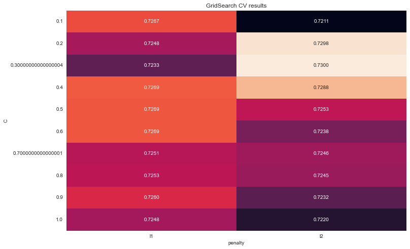

```python
score = gs.cv_results_['mean_test_score'].reshape(len(grid['C']), len(grid['penalty']))

plt.figure(figsize=(12,8))
plt.title('GridSearch CV results')
sns.heatmap(score, cbar=False, annot=True, fmt= '.4f',
            yticklabels= grid['C'], xticklabels= grid['penalty'])
plt.xlabel('penalty')
plt.ylabel('C')
plt.show()
```

```python
gs.best_params_, gs.best_score_
```

```
({'C': 0.30000000000000004, 'penalty': 'l2'}, 0.7300150551985951)
```

## Learning Curves

```python
from sklearn.linear_model import LogisticRegression
from sklearn.model_selection import learning_curve

model = LogisticRegression(penalty='l2', C = 3.0,
                           class_weight='balanced', solver='saga', max_iter=500)

train_sizes, train_scores, test_scores, fit_times, _ = learning_curve(model, X_train, y_train,
                                                         train_sizes=np.linspace(0.1, 1.0, 10), cv=5,
                                                         n_jobs=-1, scoring='f1', return_times=True)

train_scores_mean = np.mean(train_scores, axis=1)
train_scores_std = np.std(train_scores, axis=1)

test_scores_mean = np.mean(test_scores, axis=1)
test_scores_std = np.std(test_scores, axis=1)

fit_times_mean = np.mean(fit_times, axis=1)
fit_times_std = np.std(fit_times, axis=1)
```

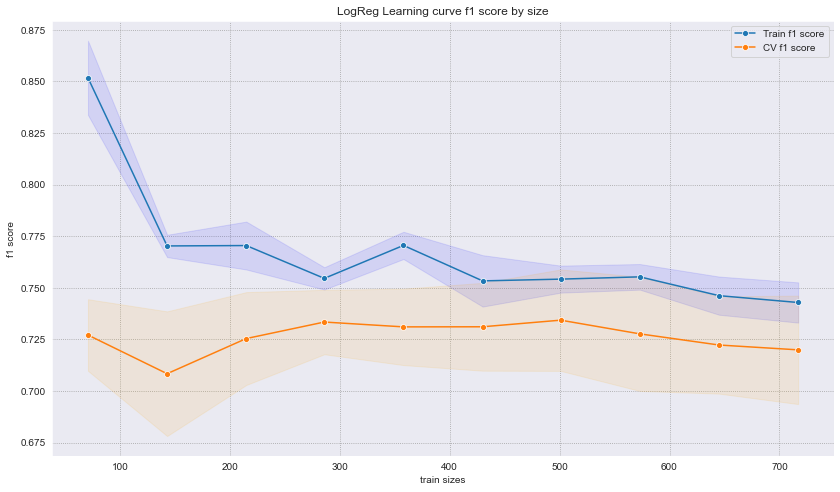

```python
plt.figure(figsize=(14,8))
plt.title('LogReg Learning curve f1 score by size')

sns.lineplot(x=train_sizes, y=train_scores_mean, marker='o')
plt.fill_between(train_sizes,train_scores_mean + train_scores_std,
                 train_scores_mean - train_scores_std, alpha = 0.1, color="b")

sns.lineplot(x=train_sizes, y=test_scores_mean, marker='o')
plt.fill_between(train_sizes, test_scores_mean + test_scores_std,
                 test_scores_mean - test_scores_std, alpha = 0.1, color='orange')

plt.legend(['Train f1 score', 'CV f1 score'])
plt.xlabel('train sizes')
plt.ylabel('f1 score')
plt.show()
```

Кривые обучения сходятся, но далеко от 1. Мы уже сталкивались с тем, что данных недостаточно при построении кривых обучения для knn, тут та же проблема, плюс для модели логистической регрессии данные могут быть плохого качества или сама модель не очень хорошо с ними работает.

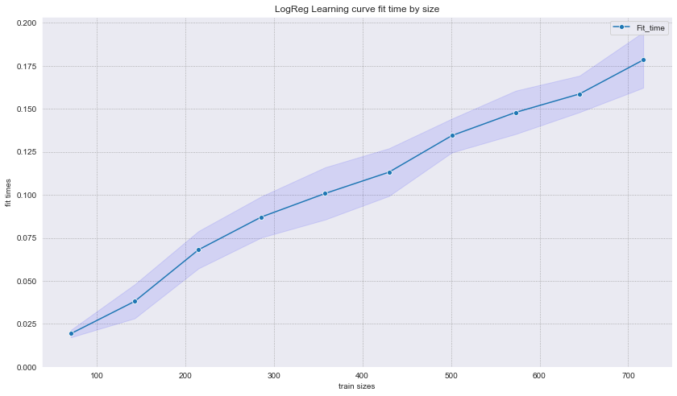

```python
plt.figure(figsize=(14,8))
plt.title('LogReg Learning curve fit time by size')

sns.lineplot(x=train_sizes, y=fit_times_mean,  marker='o')
plt.fill_between(train_sizes, fit_times_mean + fit_times_std,
                 fit_times_mean - fit_times_std, alpha = 0.1, color="b")


plt.legend(['Fit_time'])
plt.xlabel('train sizes')
plt.ylabel('fit times')
plt.ylim(0)
plt.show()
```

И логично, что у логистической регрессии в отличие от knn время на обучения растет с увеличением объема выборки, рост линейный.

## fit-predict

Обучим модель и сделаем предсказания для тестовой выборки.

```python
from sklearn.linear_model import LogisticRegression
from sklearn.metrics import classification_report

model = LogisticRegression(penalty='l2', C = 3.0,
                           class_weight='balanced', solver='saga', max_iter=1000)
model.fit(X_train, y_train)
y_pred = model.predict(X_test)

print(classification_report(y_test, y_pred))
```

```
              precision    recall  f1-score   support

           0       0.57      0.67      0.61       168
           1       0.77      0.69      0.73       275

    accuracy                           0.68       443
   macro avg       0.67      0.68      0.67       443
weighted avg       0.69      0.68      0.68       443
```

Результаты плюс минус сопоставимы, но у knn чуть лучше.

# LinearSVC

Было решено использовать SVM с линейным ядром, чтобы не тратить слишком много времени на тюннинг и обучение модели с другими ядрами.

## Grid Search

Аналогично для линейного SVC перебираем способ регуляризации и обратный коэффициент.

*Сетка для обратного коэфа регуляризации: 0.1, 0.2, 0.3, 0.4, 0.5, 0.6, 0.7, 0.8, 0.9, 1*

*Сетка для способа регуляризации: l1 (Lasso), l2 (Ridge)*

*Оценивание по метрике f1 с помощью кросс валидации на 5 фолдах*

```python
from sklearn.svm import LinearSVC
from sklearn.model_selection import GridSearchCV

grid = {'C' : np.linspace(0.1, 1, 10),
        'penalty': ('l1', 'l2')
       }

model = LinearSVC(class_weight='balanced', dual=False)

gs = GridSearchCV(model, param_grid=grid, scoring='f1', cv=5, n_jobs=-1)

gs.fit(X_train, y_train)
```

```
GridSearchCV(cv=5, estimator=LinearSVC(class_weight='balanced', dual=False),
             n_jobs=-1,
             param_grid={'C': array([0.1, 0.2, 0.3, 0.4, 0.5, 0.6, 0.7, 0.8, 0.9, 1. ]),
                         'penalty': ('l1', 'l2')},
             scoring='f1')
```

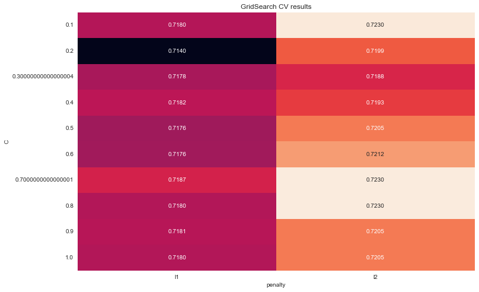

```python
score = gs.cv_results_['mean_test_score'].reshape(len(grid['C']), len(grid['penalty']))

plt.figure(figsize=(12,8))
plt.title('GridSearch CV results')
sns.heatmap(score, cbar=False, annot=True, fmt= '.4f',
            yticklabels= grid['C'], xticklabels= grid['penalty'])
plt.xlabel('penalty')
plt.ylabel('C')
plt.show()
```

```python
gs.best_params_, gs.best_score_
```

```
({'C': 0.7000000000000001, 'penalty': 'l2'}, 0.7230069629138649)
```

Видно, что лучшие результаты при l2 регуляризации с обратным коэффициентом 0.7

## Learning Curves

Построим кривые обучения

```python
from sklearn.svm import LinearSVC
from sklearn.model_selection import learning_curve

model = LinearSVC(penalty='l2',C = 7.0,
                  class_weight='balanced', dual=False)

train_sizes, train_scores, test_scores, fit_times, _ = learning_curve(model, X_train, y_train,
                                                         train_sizes=np.linspace(0.1, 1.0, 10), cv=5,
                                                         n_jobs=-1, scoring='f1', return_times=True)

train_scores_mean = np.mean(train_scores, axis=1)
train_scores_std = np.std(train_scores, axis=1)

test_scores_mean = np.mean(test_scores, axis=1)
test_scores_std = np.std(test_scores, axis=1)

fit_times_mean = np.mean(fit_times, axis=1)
fit_times_std = np.std(fit_times, axis=1)
```

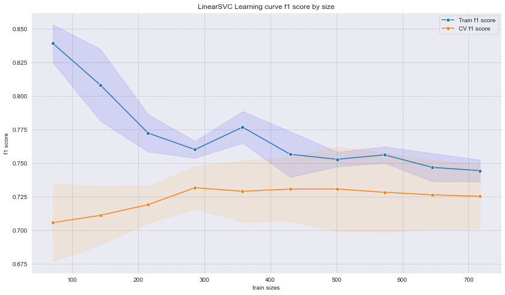

```python
plt.figure(figsize=(14,8))
plt.title('LinearSVC Learning curve f1 score by size')

sns.lineplot(x=train_sizes, y=train_scores_mean, marker='o')
plt.fill_between(train_sizes,train_scores_mean + train_scores_std,
                 train_scores_mean - train_scores_std, alpha = 0.1, color="b")

sns.lineplot(x=train_sizes, y=test_scores_mean, marker='o')
plt.fill_between(train_sizes, test_scores_mean + test_scores_std,
                 test_scores_mean - test_scores_std, alpha = 0.1, color='orange')

plt.legend(['Train f1 score', 'CV f1 score'])
plt.xlabel('train sizes')
plt.ylabel('f1 score')
plt.show()
```

Точно такая же ситуация, как и у логистической регрессии. Недостаток данных, плохое качество этих данных либо плохая модель для таких данных.

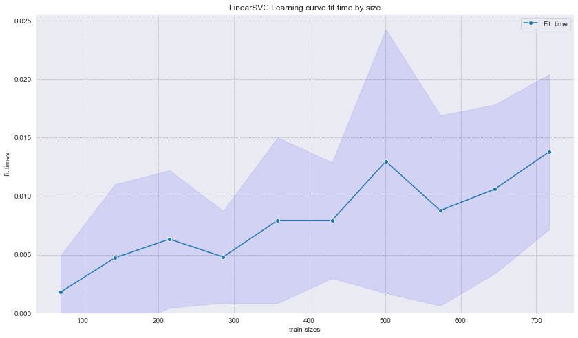

```python
plt.figure(figsize=(14,8))
plt.title('LinearSVC Learning curve fit time by size')

sns.lineplot(x=train_sizes, y=fit_times_mean,  marker='o')
plt.fill_between(train_sizes, fit_times_mean + fit_times_std,
                 fit_times_mean - fit_times_std, alpha = 0.1, color="b")

plt.legend(['Fit_time'])
plt.xlabel('train sizes')
plt.ylabel('fit times')
plt.ylim(0)
plt.show()
```

По времени на обучение ситуация чуть хуже, чем у логистической регрессии, так как большой разброс на фолдах

## fit-predict

Предсказания модели

```python
from sklearn.svm import LinearSVC
from sklearn.metrics import classification_report

model = LinearSVC(penalty='l2',C = 7.0,
                  class_weight='balanced', dual=False)

model.fit(X_train, y_train)
y_pred = model.predict(X_test)

print(classification_report(y_test, y_pred))
```

```
              precision    recall  f1-score   support

           0       0.56      0.66      0.61       168
           1       0.77      0.69      0.73       275

    accuracy                           0.68       443
   macro avg       0.67      0.67      0.67       443
weighted avg       0.69      0.68      0.68       443
```

Результат такой же, как у логистической регрессии.

# Выводы

Видно, что данных маловато. Всего длина выборки 1340, на обучение я беру 897 элементов, похоже, что этого недостаточно, чтобы хорошо решать задачу. Также возможно данные сильно линейно неразделимы, из-за чего при svm и логистической регрессии получаются плохие кривые обучения и результат предсказаний у них хуже, чем у KNN.